# U6614: Assignment 4

Philip Crane (plc2137)

2024-02-16

##### *Please submit your knitted .pdf file along with the corresponding R markdown (.rmd) via Courseworks by 11:59pm on Friday, February 17th.*

# 1 Load libraries

```r
library(tidyverse)
library(weights)
library(lmtest)
library(sandwich)
library(knitr)

getwd()
```

```
## [1] "C:/Users/philc/OneDrive/Desktop/Spring 2024/R/Assignments/Assignment4"
```

# 2 Aggregating to subway station-level arrest totals

### 2a) Load full set of cleaned arrest microdata (arrests.clean.rdata).

```r
load("arrests.clean.RData")
```

### 2b) Create new data frame (`st_arrests`) that aggregates microdata to station-level observations including the following information:

- `st_id`, `loc2`, total arrests

```r
st_arrests <- arrests.clean %>%
   group_by(st_id, loc2) %>%
    summarise(arrests_all = n() ) %>%
    arrange(desc(arrests_all))
```

### 2c) Plot histogram of arrests and briefly describe the distribution of arrests across stations.

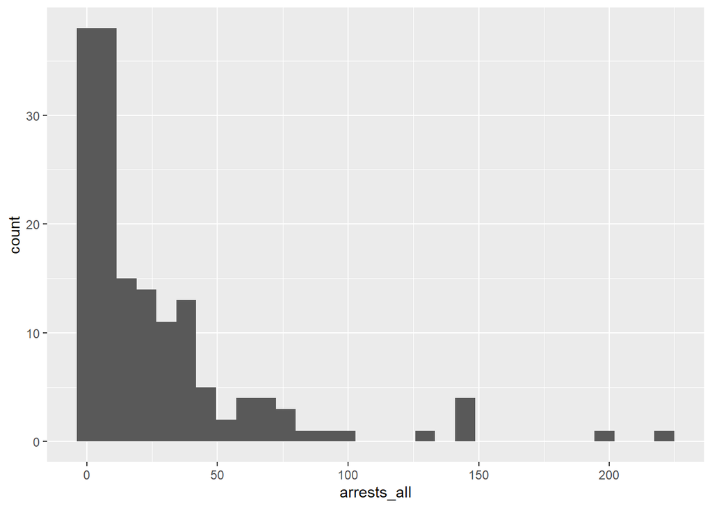

```r
ggplot(st_arrests, aes(x= arrests_all)) + geom_histogram()
```

The histogram shows an enormous difference between stations with the most arrests and those with the least. Coney Island has the most arrests by a good margin, and is the only station to exceed 200 arrests.

# 3 Joining subway ridership and neighborhood demographic data

### 3a) Read in poverty and ridership csv files with strings as factors (`station_povdataclean_2016.csv` and `Subway Ridership by Station - BK.csv`).

```r
st_poverty <- read.csv("station_povdataclean_2016.csv",
                         stringsAsFactors = TRUE)

st_ridership <- read.csv("Subway Ridership by Station - BK.csv",
                           stringsAsFactors = TRUE)
```

### 3b) Join both data frames from 3a to `st_arrests` and inspect results (store new data frame as `st_joined`).

- Inspect results from joins, drop unnecessary columns from the ridership data, and group `st_joined` by `st_id` and `mta_name`.
- Only display ungrouped version of `st_joined` for compactness.

```r
 drop_vars <- c("swipes2011", "swipes2012", "swipes2013", "swipes2014", "swipes2015")

st_arrests <- st_arrests %>% mutate(st_id = as.integer(st_id))
  st_joinedtemp <- inner_join(st_arrests, st_poverty, by = c("st_id" = "st_id"))
  rm(st_joinedtemp)

st_joined <- st_arrests %>%
    inner_join(st_poverty, by = c("st_id" = "st_id")) %>%
    inner_join(st_ridership, by = c("st_id" = "st_id",
                                    "mta_name" = "mta_name")) %>%
    select(!all_of(drop_vars)) %>%
    group_by(st_id, mta_name)

st_joined %>% ungroup() %>% str(give.attr = FALSE)
```

```
## tibble [157 × 14] (S3: tbl_df/tbl/data.frame)
##  $ st_id         : int [1:157] 66 99 150 70 114 131 54 147 106 123 ...
##  $ loc2          : Factor w/ 157 levels "15 st prospect park f g line",..: 66 100 149 148 110 129 54 146 104 122 ...
##  $ arrests_all   : int [1:157] 223 198 143 142 141 141 133 102 90 86 ...
##  $ x             : num [1:157] -74 -74 -73.9 -73.9 -74 ...
##  $ y             : num [1:157] 40.6 40.7 40.7 40.7 40.7 ...
##  $ mta_name      : Factor w/ 157 levels "15 St-Prospect Park F subway G subway",..: 66 99 150 70 114 131 54 148 105 123 ...
##  $ pop_black_2016: int [1:157] 36 1939 14825 13135 1542 10311 5624 11804 16176 2698 ...
##  $ pov_black_2016: int [1:157] 2 677 4592 3796 483 2437 900 6706 3832 306 ...
##  $ pop_all_2016  : int [1:157] 5186 12437 18556 17561 23711 15934 6753 15751 20610 13654 ...
##  $ pov_all_2016  : int [1:157] 1329 1939 6149 5565 9182 3511 1156 9104 4809 1221 ...
##  $ povrt_all_2016: num [1:157] 0.256 0.156 0.331 0.317 0.387 ...
##  $ shareblack    : num [1:157] 0.00694 0.15591 0.79893 0.74796 0.06503 ...
##  $ nblack        : int [1:157] 0 0 1 1 0 1 1 1 1 0 ...
##  $ swipes2016    : int [1:157] 5025598 13091255 5152649 9051970 4272443 5861658 3897784 1435112 2031710 3220745 ...
```

```r
    summary(st_joined)
```

```
##      st_id                               loc2      arrests_all
##  Min.   :  1   15 st prospect park f g line:  1   Min.   :  2.00
##  1st Qu.: 40   1523 Avenue U               :  1   1st Qu.:  4.00
##  Median : 79   1778 w 7th st               :  1   Median : 13.00
##  Mean   : 79   18th av and 85th st         :  1   Mean   : 26.82
##  3rd Qu.:118   18th ave and 64th st        :  1   3rd Qu.: 36.00
##  Max.   :157   20th ave and 64th st        :  1   Max.   :223.00
##                (Other)                     :151
##        x                y                                          mta_name
##  Min.   :-74.03   Min.   :40.58   15 St-Prospect Park F subway G subway:  1
##  1st Qu.:-73.98   1st Qu.:40.63   18 Av  D subway                      :  1
##  Median :-73.96   Median :40.67   18 Av  F subway                      :  1
##  Mean   :-73.96   Mean   :40.66   18 Av N subway                       :  1
##  3rd Qu.:-73.93   3rd Qu.:40.69   20 Av  D subway                      :  1
##  Max.   :-73.87   Max.   :40.72   20 Av  N subway                      :  1
##                                   (Other)                              :151
##  pop_black_2016  pov_black_2016  pop_all_2016    pov_all_2016
##  Min.   :    0   Min.   :   0   Min.   : 2721   Min.   :  308
##  1st Qu.:  398   1st Qu.:  86   1st Qu.:11303   1st Qu.: 1959
##  Median : 2399   Median : 616   Median :15167   Median : 3206
##  Mean   : 4579   Mean   :1166   Mean   :15250   Mean   : 3775
##  3rd Qu.: 7504   3rd Qu.:1644   3rd Qu.:18371   3rd Qu.: 5241
##  Max.   :20739   Max.   :6706   Max.   :31071   Max.   :11612
##
##  povrt_all_2016      shareblack          nblack        swipes2016
##  Min.   :0.03321   Min.   :0.00000   Min.   :0.000   Min.   :  406793
##  1st Qu.:0.16348   1st Qu.:0.02366   1st Qu.:0.000   1st Qu.: 1188884
##  Median :0.22859   Median :0.15819   Median :0.000   Median : 1863036
##  Mean   :0.24010   Mean   :0.29328   Mean   :0.293   Mean   : 2449301
##  3rd Qu.:0.30144   3rd Qu.:0.54165   3rd Qu.:1.000   3rd Qu.: 3027658
##  Max.   :0.57800   Max.   :0.88898   Max.   :1.000   Max.   :13818168
##
```

### 3c) Print the top 10 stations by total arrest counts

- Only display `st_id`, `mta_name`, `arrests_all`, `shareblack`, `povrt_all_2016` (no other columns)

```r
st_joined %>%
    arrange(desc(arrests_all)) %>%
    select(st_id, mta_name, arrests_all, shareblack, povrt_all_2016) %>%
    head(n = 10)
```

```
## # A tibble: 10 × 5
##    st_id mta_name                          arrests_all shareblack povrt_all_2016
##    <int> <fct>                                   <int>      <dbl>          <dbl>
##  1    66 "Coney Island-Stillwell Av D sub…         223    0.00694         0.256
##  2    99 "Jay St-MetroTech A subway C sub…         198    0.156           0.156
##  3   150 "Utica Av  A subway C subway "            143    0.799           0.331
##  4    70 "Crown Heights-Utica Av 3 subway…         142    0.748           0.317
##  5   114 "Marcy Av  J subway M subway Z s…         141    0.0650          0.387
##  6   131 "Nostrand Av  A subway C subway"          141    0.647           0.220
##  7    54 "Canarsie-Rockaway Pkwy L subway"         133    0.833           0.171
##  8   147 "Sutter Av  L subway"                     102    0.749           0.578
##  9   106 "Kingston-Throop Avs C subway"             90    0.785           0.233
## 10   123 "Nevins St  2 subway 3 subway 4 …          86    0.198           0.0894
```

# 4 Explore relationship between arrest intensity and poverty rates across subway station (areas)

### 4a) Compute arrest intensity and other explanatory variables for analysis.

- Drop the observation for the Coney Island station and very briefly explain your logic
- Create new column of data for the following:
  - fare evasion arrest intensity: `arrperswipe_2016` = arrests per 100,000 ridership (‘swipes’)
  - a dummy indicating if a station is high poverty: `highpov` = 1 if pov rate is > median pov rate across all Brooklyn station areas
  - a dummy for majority Black station areas: `nblack` = 1 if `shareblack` > 0.5
- Coerce new dummy variables into factors with category labels
- Assign results to new data frame called `stations`
- Display top 10 station areas by arrest intensity using `kable()` in the `knitr` package

```r
stations <- st_joined %>%
    mutate(arrperswipe = round(arrests_all / (swipes2016/100000), 2),
           highpov = as.numeric(povrt_all_2016 > median(st_joined$povrt_all_2016)),
           nblack = as.numeric(shareblack > .5),
           shareblack = round(shareblack, 2),
           povrt_all_2016 = round(povrt_all_2016, 2)) %>%
    mutate(highpov = factor(highpov, levels = c(0,1),
                            labels = c("Not high poverty", "High poverty")),
           nblack  = factor(nblack, levels = c(0,1),
                            labels = c("Majority non-Black", "Majority Black"))) %>%
    filter(st_id != 66)

stations %>%
    arrange(desc(arrperswipe)) %>%
    select(st_id, mta_name, arrperswipe, arrests_all, shareblack, povrt_all_2016, highpov, nblack) %>%
    head(n = 10) %>%
    kable()
```

| st_id | mta_name | arrperswipe | arrests_all | shareblack | povrt_all_2016 | highpov | nblack |
| --- | --- | --- | --- | --- | --- | --- | --- |
| 101 | Junius St 3 subway | 11.00 | 75 | 0.78 | 0.48 | High poverty | Majority Black |
| 26 | Atlantic Av L subway | 8.48 | 37 | 0.66 | 0.51 | High poverty | Majority Black |
| 111 | Livonia Av L subway | 7.17 | 75 | 0.83 | 0.45 | High poverty | Majority Black |
| 147 | Sutter Av L subway | 7.11 | 102 | 0.75 | 0.58 | High poverty | Majority Black |
| 106 | Kingston-Throop Avs C subway | 4.43 | 90 | 0.78 | 0.23 | High poverty | Majority Black |
| 112 | Lorimer St J subway M subway | 4.39 | 70 | 0.15 | 0.34 | High poverty | Majority non-Black |
| 140 | Rockaway Av 3 subway | 3.97 | 61 | 0.78 | 0.40 | High poverty | Majority Black |
| 54 | Canarsie-Rockaway Pkwy L subway | 3.41 | 133 | 0.83 | 0.17 | Not high poverty | Majority Black |
| 141 | Rockaway Av C subway | 3.41 | 61 | 0.80 | 0.22 | Not high poverty | Majority Black |
| 144 | Shepherd Av C subway | 3.40 | 36 | 0.61 | 0.30 | High poverty | Majority Black |

### 4b) Examine the relationship between arrest intensity and poverty rates

- Show a scatterplot of arrest intensity vs. poverty rates along with the regression line you think best fits this relationship.
- Which regression specification do you prefer: linear or quadratic? Be clear about your logic and if applicable cite statistical evidence to support your decision.
- Explain your logic about whether to weight observations or not.
- Interpret your preferred regression specification (carefully!).

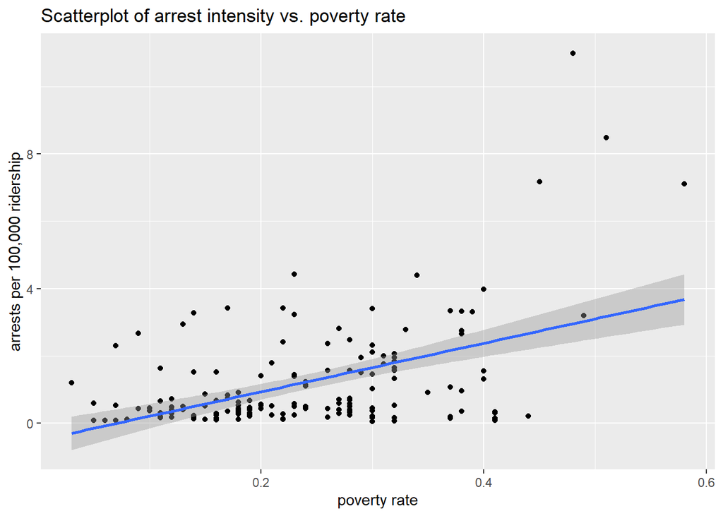

```r
ggplot(stations,
       aes(x = povrt_all_2016, y = arrperswipe)) +
  geom_point() +
  ggtitle('Scatterplot of arrest intensity vs. poverty rate') +
  labs(x = 'poverty rate', y = 'arrests per 100,000 ridership') +
  geom_smooth(method = 'lm', formula=y~x)
```

```r
ols1l <- lm(arrperswipe ~ povrt_all_2016, data = stations, weights = swipes2016)
ols1q <- lm(arrperswipe ~ povrt_all_2016 + I(povrt_all_2016^2),
            data = stations, weights = swipes2016)
summary(ols1q)
```

```
##
## Call:
## lm(formula = arrperswipe ~ povrt_all_2016 + I(povrt_all_2016^2),
##     data = stations, weights = swipes2016)
##
## Weighted Residuals:
##     Min      1Q  Median      3Q     Max
## -4044.5  -863.9  -330.4   656.8  6182.4
##
## Coefficients:
##                     Estimate Std. Error t value Pr(>|t|)
## (Intercept)           1.2865     0.3841   3.349 0.001020 **
## povrt_all_2016       -8.1441     3.4376  -2.369 0.019080 *
## I(povrt_all_2016^2)  26.6321     6.9564   3.828 0.000188 ***
## ---
## Signif. codes:  0 '***' 0.001 '**' 0.01 '*' 0.05 '.' 0.1 ' ' 1
##
## Residual standard error: 1659 on 153 degrees of freedom
## Multiple R-squared:  0.2249, Adjusted R-squared:  0.2148
## F-statistic:  22.2 on 2 and 153 DF,  p-value: 3.426e-09
```

```r
coeftest(ols1q, vcov = vcovHC(ols1q, type = "HC1"))
```

```
##
## t test of coefficients:
##
##                     Estimate Std. Error t value Pr(>|t|)
## (Intercept)          1.28648    0.39608  3.2480 0.001428 **
## povrt_all_2016      -8.14412    3.99163 -2.0403 0.043040 *
## I(povrt_all_2016^2) 26.63207    9.07709  2.9340 0.003862 **
## ---
## Signif. codes:  0 '***' 0.001 '**' 0.01 '*' 0.05 '.' 0.1 ' ' 1
```

```r
summary(ols1l)
```

```
##
## Call:
## lm(formula = arrperswipe ~ povrt_all_2016, data = stations, weights = swipes2016)
##
## Weighted Residuals:
##     Min      1Q  Median      3Q     Max
## -3197.5  -904.3  -364.7   541.3  7222.3
##
## Coefficients:
##                Estimate Std. Error t value Pr(>|t|)
## (Intercept)     0.04023    0.21273   0.189     0.85
## povrt_all_2016  4.61213    0.88237   5.227 5.53e-07 ***
## ---
## Signif. codes:  0 '***' 0.001 '**' 0.01 '*' 0.05 '.' 0.1 ' ' 1
##
## Residual standard error: 1731 on 154 degrees of freedom
## Multiple R-squared:  0.1507, Adjusted R-squared:  0.1452
## F-statistic: 27.32 on 1 and 154 DF,  p-value: 5.528e-07
```

```r
coeftest(ols1l, vcov = vcovHC(ols1l, type = "HC1"))
```

```
##
## t test of coefficients:
##
##                Estimate Std. Error t value  Pr(>|t|)
## (Intercept)    0.040233   0.242262  0.1661 0.8683166
## povrt_all_2016 4.612128   1.182665  3.8998 0.0001434 ***
## ---
## Signif. codes:  0 '***' 0.001 '**' 0.01 '*' 0.05 '.' 0.1 ' ' 1
```

### 4c) Estimate and test the difference in mean arrest intensity between high/low poverty areas

- Report difference and assess statistical significance
- Weight observations by ridership

```r
diff1 <- lm(arrperswipe ~ highpov, data = stations, weight = swipes2016)
    summary(diff1)
```

```
##
## Call:
## lm(formula = arrperswipe ~ highpov, data = stations, weights = swipes2016)
##
## Weighted Residuals:
##     Min      1Q  Median      3Q     Max
## -2947.1  -916.2  -410.8   656.2  7914.3
##
## Coefficients:
##                     Estimate Std. Error t value Pr(>|t|)
## (Intercept)           0.7829     0.1225   6.392 1.85e-09 ***
## highpovHigh poverty   0.6332     0.1884   3.360 0.000981 ***
## ---
## Signif. codes:  0 '***' 0.001 '**' 0.01 '*' 0.05 '.' 0.1 ' ' 1
##
## Residual standard error: 1813 on 154 degrees of freedom
## Multiple R-squared:  0.06832,    Adjusted R-squared:  0.06227
## F-statistic: 11.29 on 1 and 154 DF,  p-value: 0.0009815
```

```r
    coeftest(diff1, vcov = vcovHC(diff1, type="HC1"))
```

```
##
## t test of coefficients:
##
##                     Estimate Std. Error t value  Pr(>|t|)
## (Intercept)          0.78293    0.11127  7.0365 6.077e-11 ***
## highpovHigh poverty  0.63316    0.19953  3.1732  0.001821 **
## ---
## Signif. codes:  0 '***' 0.001 '**' 0.01 '*' 0.05 '.' 0.1 ' ' 1
```

# 5 How does neighborhood racial composition mediate the relationship between poverty and arrest intensity?

- In this section, you will examine the relationship between arrest intensity & poverty by Black vs. non-Black station area (`nblack`).

### 5a) Present a table showing the difference in mean arrests intensity for each group in a 2x2 table of `highpov` vs `nblack`.

- Remember to weight by ridership at each station
- Could the difference in arrest intensity be explained by differences in poverty rate?

```r
t1_arrper_wtd <-
  with(stations,
       tapply(arrperswipe * swipes2016,
              list(highpov, nblack),
              sum))  /
  with(stations,
       tapply(swipes2016,
              list(highpov, nblack),
              sum) )

t1_arrper_wtd <- t1_arrper_wtd %>% round(2)
t1_arrper_wtd
```

```
##                  Majority non-Black Majority Black
## Not high poverty               0.66           1.19
## High poverty                   0.82           2.49
```

### 5b) Show a scatterplot of arrest intensity vs. poverty rates (with separate aesthetics for Black and non-Black station areas) along with the regression line you think best fits this relationship.

- Which regression specification do you prefer: linear or quadratic? Be clear about your logic and if applicable cite statistical evidence to support your decision.
- Interpret your preferred regression specification (carefully!).

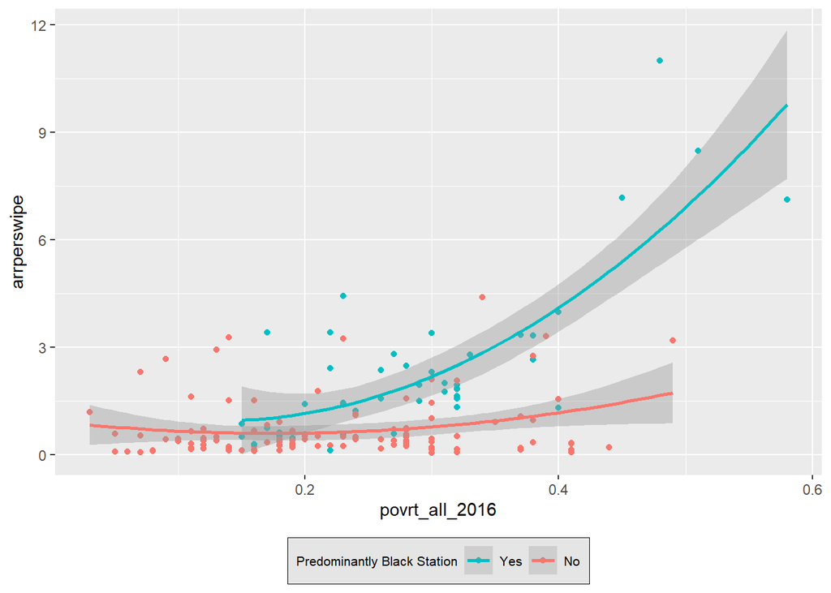

```r
ggplot(stations, aes(x = povrt_all_2016, y = arrperswipe, color = nblack)) +
    geom_point() +
    scale_color_discrete(name = "Predominantly Black Station",
                         labels=c("No", "Yes"),
                         guide = guide_legend(reverse=TRUE)) +
    theme(legend.position = "bottom",
          legend.background = element_rect(color = "black", fill = "grey90", size = .2, linetype = "solid"),
          legend.direction = "horizontal",
          legend.text = element_text(size = 8),
          legend.title = element_text(size = 8) ) +
    geom_smooth(method = "lm", formula = y~x + I(x^2))
```

```r
stations_black <- stations %>%
  filter(nblack == "Majority Black")

stations_non_black <- stations %>%
  filter(nblack == "Majority non-Black")

ols2qb <- lm(arrperswipe ~ povrt_all_2016 + I(povrt_all_2016^2), data = stations_black)
ols2qnb <- lm(arrperswipe ~ povrt_all_2016 + I(povrt_all_2016^2), data = stations_non_black)

summary(ols2qb)
```

```
##
## Call:
## lm(formula = arrperswipe ~ povrt_all_2016 + I(povrt_all_2016^2),
##     data = stations_black)
##
## Residuals:
##     Min      1Q  Median      3Q     Max
## -2.8004 -0.6455 -0.2596  0.2268  4.7304
##
## Coefficients:
##                     Estimate Std. Error t value Pr(>|t|)
## (Intercept)            1.731      1.644   1.053  0.29813
## povrt_all_2016       -11.737     10.560  -1.112  0.27253
## I(povrt_all_2016^2)   44.150     15.713   2.810  0.00743 **
## ---
## Signif. codes:  0 '***' 0.001 '**' 0.01 '*' 0.05 '.' 0.1 ' ' 1
##
## Residual standard error: 1.346 on 43 degrees of freedom
## Multiple R-squared:  0.6493, Adjusted R-squared:  0.633
## F-statistic: 39.81 on 2 and 43 DF,  p-value: 1.642e-10
```

```r
summary(ols2qnb)
```

```
##
## Call:
## lm(formula = arrperswipe ~ povrt_all_2016 + I(povrt_all_2016^2),
##     data = stations_non_black)
##
## Residuals:
##     Min      1Q  Median      3Q     Max
## -1.1954 -0.4587 -0.2425  0.0692  3.4834
##
## Coefficients:
##                     Estimate Std. Error t value Pr(>|t|)
## (Intercept)           0.9399     0.3716   2.530   0.0129 *
## povrt_all_2016       -3.9510     3.3919  -1.165   0.2467
## I(povrt_all_2016^2)  11.3320     6.9337   1.634   0.1051
## ---
## Signif. codes:  0 '***' 0.001 '**' 0.01 '*' 0.05 '.' 0.1 ' ' 1
##
## Residual standard error: 0.8433 on 107 degrees of freedom
## Multiple R-squared:  0.05345,    Adjusted R-squared:  0.03576
## F-statistic: 3.021 on 2 and 107 DF,  p-value: 0.05293
```

### 5c) Next let’s let’s think about how measurement error might impact results from 5b. Do you think measurement error could bias your estimates of neighborhood racial gaps in the effect of poverty on enforcement intensity from 5b? Explain, carefully. Do you have any creative ideas to address any concerns you have about potential bias due to measurement error?

- One source of measurement error owes to the fact that we’re using racial-ethnic composition and poverty rates for the neighborhood surrounding each station to proxy for characteristics of riders at each station. These variables are measured with *non-random* error; demographic measures for the surrounding neighborhood will tend to be a less accurate proxy for the demographics of riders at that station for busier stations that are destinations for commuters, tourists and others who may not live in very vicinity close to the station.
- Tip: this is a very tricky issue! In order to think through the measurement error problem and it’s consequences you will probably want to consult your Quant II notes and/or my Quant II [video lecture 4](https://drive.google.com/file/d/1CsVY04W1EPQQIE4WUP5p-rkXXJLWv5FS/view?usp=sharing) on the course website.
- Can you think of any other measurement error problems that might affect your results from 5b?
- Do you have any creative ideas for addressing any concerns you have about potential bias due to this source of measurement error, using this data or other data you think might exist?

# 6 Examine the relationship between arrest intensity and crime

### 6a) Load the crime data (`nypd_criminalcomplaints_2016.csv`) and join to the existing `stations` data frame.

```r
st_complaint <- read.csv("nypd_criminalcomplaints_2016.csv",
                         stringsAsFactors = TRUE)

stations <-
    inner_join(stations, st_complaint, by = c("st_id" = "st_id"))
```

*NOTE: For the next two subsections, present your preferred plots to inform the relationships in question, along with any additional data manipulation and evidence to support your decisions/interpretation/conclusions. You’ll want to explore the data before arriving at your preferred plots, but don’t present everything you tried along the way such as intermediate versions of your preferred plot. Focus on the analysis you eventually settled on to best inform the question at hand, and any critical observations that led you down this path.*

### 6b) Examine the overall relationship between arrest intensity and crime (without taking neighborhood racial composition or poverty into account) (comparable to Section 4b). Carefully interpret the results you choose to present.

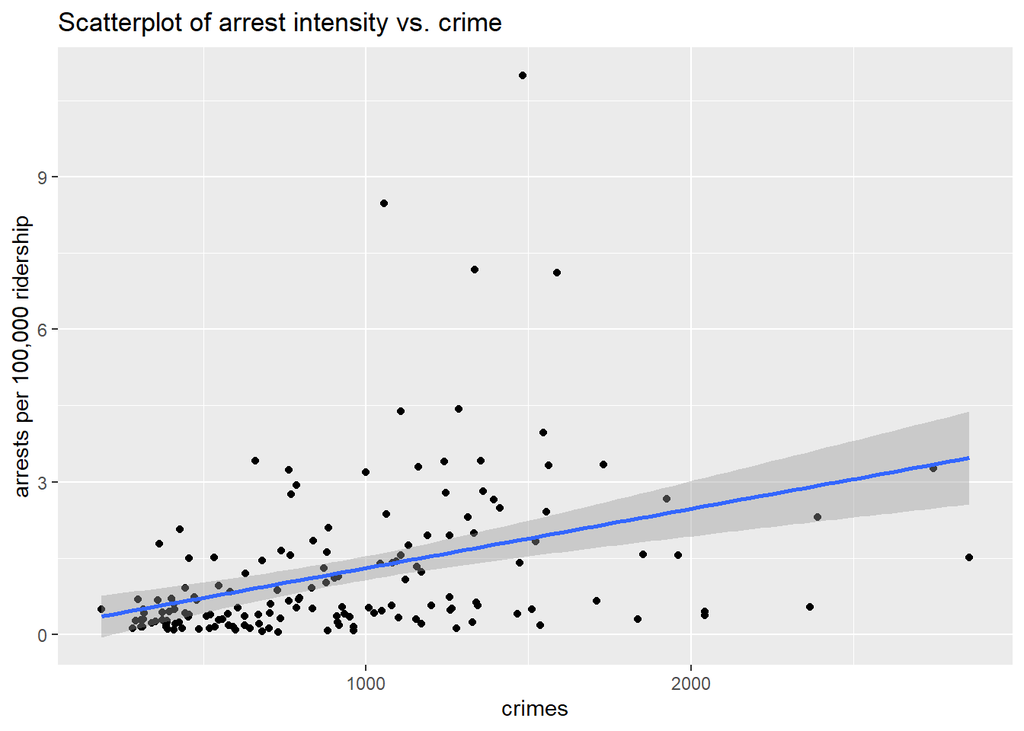

```r
ggplot(stations,
       aes(x = crimes, y = arrperswipe)) +
  geom_point() +
  ggtitle('Scatterplot of arrest intensity vs. crime') +
  labs(x = 'crimes', y = 'arrests per 100,000 ridership') +
  geom_smooth(method = 'lm', formula=y~x)
```

```r
ols2l <- lm(arrperswipe~crimes, data=stations, weights=swipes2016)

summary(ols2l)
```

```
##
## Call:
## lm(formula = arrperswipe ~ crimes, data = stations, weights = swipes2016)
##
## Weighted Residuals:
##     Min      1Q  Median      3Q     Max
## -4275.4  -836.5  -268.3   962.8  8046.7
##
## Coefficients:
##              Estimate Std. Error t value Pr(>|t|)
## (Intercept) 0.4416058  0.1879539    2.35 0.020066 *
## crimes      0.0005490  0.0001476    3.72 0.000279 ***
## ---
## Signif. codes:  0 '***' 0.001 '**' 0.01 '*' 0.05 '.' 0.1 ' ' 1
##
## Residual standard error: 1799 on 154 degrees of freedom
## Multiple R-squared:  0.08244,    Adjusted R-squared:  0.07648
## F-statistic: 13.84 on 1 and 154 DF,  p-value: 0.0002788
```

```r
coeftest(ols2l, vcov = vcovHC(ols2l, type="HC1"))
```

```
##
## t test of coefficients:
##
##               Estimate Std. Error t value Pr(>|t|)
## (Intercept) 0.44160583 0.16918745  2.6102 0.009944 **
## crimes      0.00054901 0.00018379  2.9871 0.003278 **
## ---
## Signif. codes:  0 '***' 0.001 '**' 0.01 '*' 0.05 '.' 0.1 ' ' 1
```

### 6c) Examine how neighborhood racial composition mediates the relationship between arrest intensity and crime (comparable to Section 5b). Carefully interpret the results you choose to present.

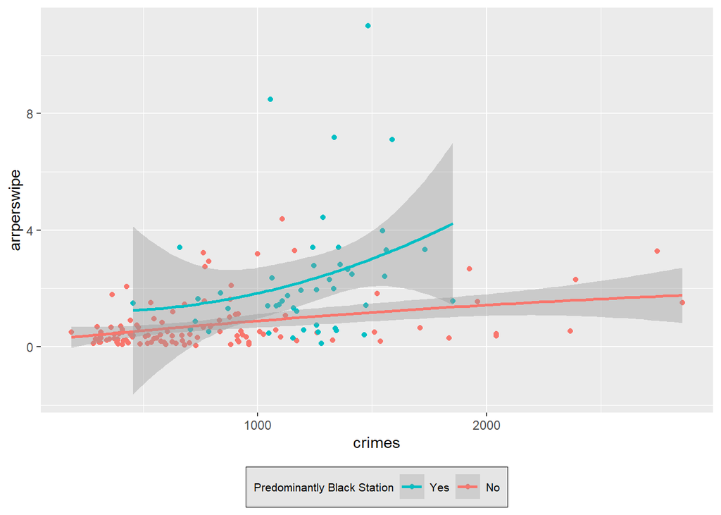

```r
ggplot(stations, aes(x = crimes, y = arrperswipe, color = nblack)) +
    geom_point() +
    #Modify legend title and text
    scale_color_discrete(name = "Predominantly Black Station",
                         labels=c("No", "Yes"),
                         #Reverse Label Order
                         guide = guide_legend(reverse=TRUE)) +
    #Modify legend aesthetics (optional)
    theme(legend.position = "bottom",
          legend.background = element_rect(color = "black", fill = "grey90", size = .2, linetype = "solid"),
          legend.direction = "horizontal",
          legend.text = element_text(size = 8),
          legend.title = element_text(size = 8) ) +
    geom_smooth(method = "lm", formula = y~x + I(x^2))
```

```r
ols3l <- lm(arrperswipe ~ crimes + nblack + (nblack * crimes), data = stations)
  summary(ols3l)
```

```
##
## Call:
## lm(formula = arrperswipe ~ crimes + nblack + (nblack * crimes),
##     data = stations)
##
## Residuals:
##     Min      1Q  Median      3Q     Max
## -2.5037 -0.5457 -0.2700  0.2141  8.0623
##
## Coefficients:
##                               Estimate Std. Error t value Pr(>|t|)
## (Intercept)                  0.2747539  0.2323348   1.183   0.2388
## crimes                       0.0005770  0.0002402   2.402   0.0175 *
## nblackMajority Black        -0.4870588  0.8912327  -0.547   0.5855
## crimes:nblackMajority Black  0.0015471  0.0007334   2.109   0.0365 *
## ---
## Signif. codes:  0 '***' 0.001 '**' 0.01 '*' 0.05 '.' 0.1 ' ' 1
##
## Residual standard error: 1.345 on 152 degrees of freedom
## Multiple R-squared:  0.2892, Adjusted R-squared:  0.2751
## F-statistic: 20.61 on 3 and 152 DF,  p-value: 2.931e-11
```

```r
  coeftest(ols3l, vcov = vcovHC(ols3l, type = "HC1"))
```

```
##
## t test of coefficients:
##
##                                Estimate  Std. Error t value  Pr(>|t|)
## (Intercept)                  0.27475389  0.11564853  2.3758 0.0187589 *
## crimes                       0.00057698  0.00015757  3.6616 0.0003453 ***
## nblackMajority Black        -0.48705879  1.10292270 -0.4416 0.6594009
## crimes:nblackMajority Black  0.00154711  0.00100483  1.5397 0.1257189
## ---
## Signif. codes:  0 '***' 0.001 '**' 0.01 '*' 0.05 '.' 0.1 ' ' 1
```

# 7 Summarize and interpret your findings with respect to subway fare evasion enforcement bias based on race

- Is there any additional analysis you’d like to explore with the data at hand?
- Are there any key limitations to the data and/or analysis affecting your ability to assess enforcement bias based on race?
- Is there any additional data you’d like to see that would help strengthen your analysis and interpretation?
- For this question, try to be specific and avoid vaguely worded concerns.